# Лабораторная работа №5.1

Бабикова Евгения

10 12 2017

# Дисперсионный анализ

## Работа с исходными данными

Исходные данные имеют следующий вид:

```
##      gender            Age            Height        pre.weight
##  Min.   :0.0000   Min.   :16.00   Min.   :141.0   Min.   : 58.00
##  1st Qu.:0.0000   1st Qu.:32.25   1st Qu.:164.2   1st Qu.: 66.00
##  Median :0.0000   Median :39.00   Median :169.5   Median : 72.00
##  Mean   :0.4342   Mean   :39.15   Mean   :170.8   Mean   : 72.53
##  3rd Qu.:1.0000   3rd Qu.:46.75   3rd Qu.:174.8   3rd Qu.: 78.00
##  Max.   :1.0000   Max.   :60.00   Max.   :201.0   Max.   :103.00
##  NA's   :2
##       Diet        weight6weeks
##  Min.   :1.000   Min.   : 53.00
##  1st Qu.:1.000   1st Qu.: 61.85
##  Median :2.000   Median : 68.95
##  Mean   :2.038   Mean   : 68.68
##  3rd Qu.:3.000   3rd Qu.: 73.83
##  Max.   :3.000   Max.   :103.00
##
```

После переименования колнок и добавление новой колонки weight.loss, данные выглядят так:

```
##      gender            age            height      initial.weight
##  Min.   :0.0000   Min.   :16.00   Min.   :141.0   Min.   : 58.00
##  1st Qu.:0.0000   1st Qu.:32.25   1st Qu.:164.2   1st Qu.: 66.00
##  Median :0.0000   Median :39.00   Median :169.5   Median : 72.00
##  Mean   :0.4342   Mean   :39.15   Mean   :170.8   Mean   : 72.53
##  3rd Qu.:1.0000   3rd Qu.:46.75   3rd Qu.:174.8   3rd Qu.: 78.00
##  Max.   :1.0000   Max.   :60.00   Max.   :201.0   Max.   :103.00
##  NA's   :2
##  diet.type  final.weight     weight.loss
##  A:24      Min.   : 53.00   Min.   :-2.100
##  B:27      1st Qu.: 61.85   1st Qu.: 2.000
##  C:27      Median : 68.95   Median : 3.600
##            Mean   : 68.68   Mean   : 3.845
##            3rd Qu.: 73.83   3rd Qu.: 5.550
##            Max.   :103.00   Max.   : 9.200
##
```

## Анализ исходных данных

Диаграммы размаха по типам диет:

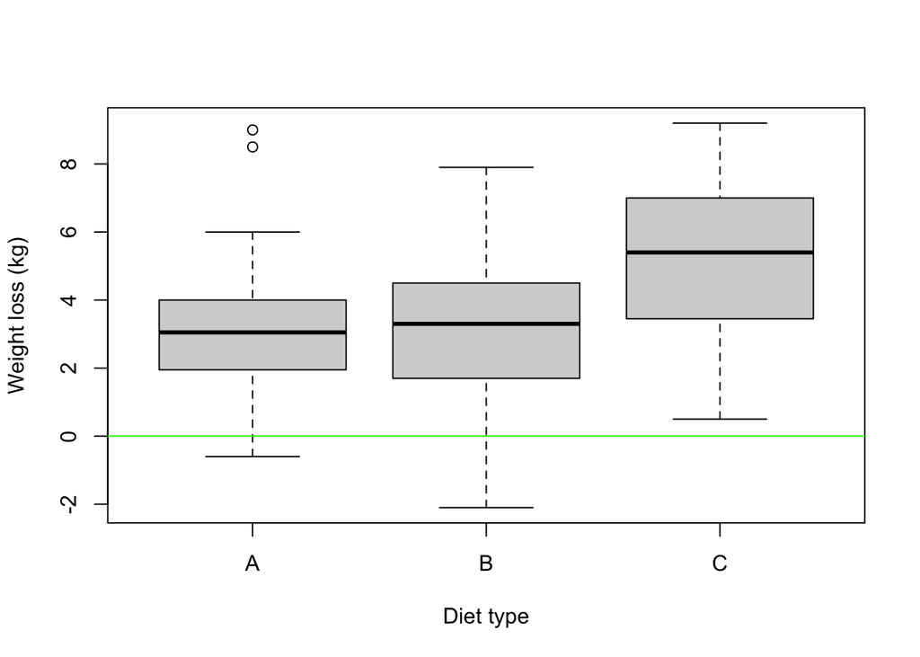

По диаграммам размаха видно, что по типам диет есть различия. Например, при диете С наблюдается наибольшая потеря килограм, а при диете B - даже набор веса, а две точки над “ящиком” диеты А, выбивающиеся из общей картины, могут являться выбросами.

Данные по типам диет не являются сбалансированными, так как в диете А число наблюдений другое, чем в В и С:

```
##
##  A  B  C
## 24 27 27
```

Размер выборки больше, чем десятикратное количество групп.

Групповые средние для типов диет:

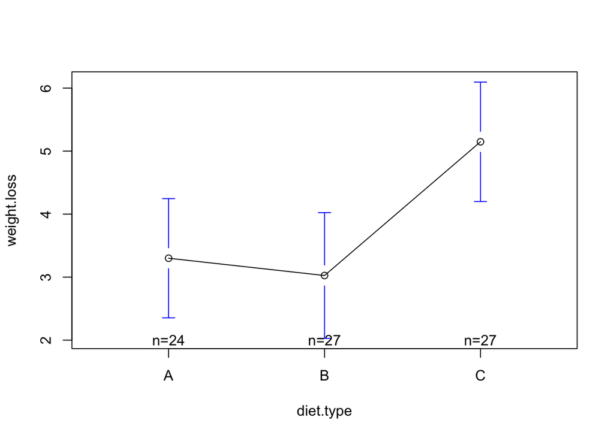

Суммарная статистика по типам диет относительно стандартного отклонения:

```
##   Group.1        x
## 1       A 2.240148
## 2       B 2.523367
## 3       C 2.395568
```

Стандартное отклонение для всех групп примерно одинаковое. По эффективности побеждает диета C, а уступает другим - B.

Подгонка дисперсионного анализа с помощью функции ``aov()` ` - частный случай линейной модели lm.

```
##             Df Sum Sq Mean Sq F value  Pr(>F)
## diet.type    2   71.1   35.55   6.197 0.00323 **
## Residuals   75  430.2    5.74
## ---
## Signif. codes:  0 '***' 0.001 '**' 0.01 '*' 0.05 '.' 0.1 ' ' 1
```

Результат F-теста свидетельствует, что разные по типу диеты неодинаково эффективны, однако отсюда нельзя понять, какие именно диеты различаются между собой.

Для ответа на этот вопрос используются множественные сравнения. Попарные различия между средними значениями для всех групп реализованы с помощью функции `TukeyHSD()`:

```
##   Tukey multiple comparisons of means
##     95% family-wise confidence level
##
## Fit: aov(formula = weight.loss ~ diet.type, data = data)
##
## $diet.type
##           diff        lwr      upr     p adj
## B-A -0.2740741 -1.8806155 1.332467 0.9124737
## C-A  1.8481481  0.2416067 3.454690 0.0201413
## C-B  2.1222222  0.5636481 3.680796 0.0047819
```

Из полученных результатов видно, что между типами диет А и В нет статистической разницы, когда между C и B она более значительна.

Визуализация межгрупповых различий:

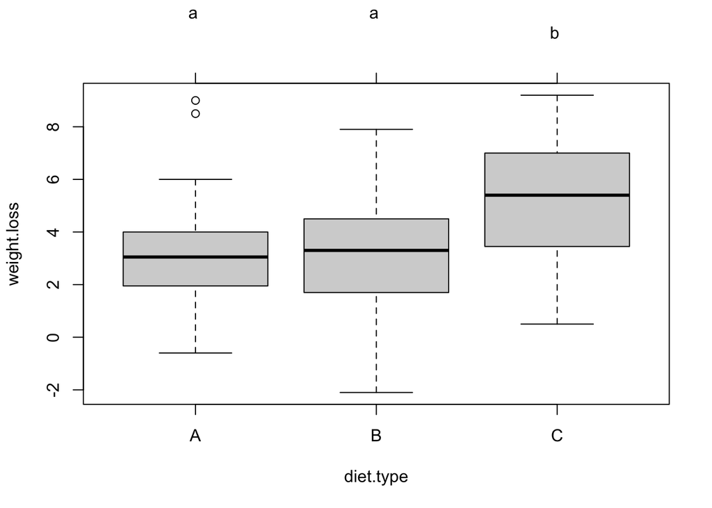

Видно, что диеты А и B статистически не отличаются (обозначены одинаковыми буквами), а С - сильно отличается от предыдущих двух.

## Избавление от выбросов

Выбросами можно считать набор веса при соблюдении диеты, а также два значения, выбивающиеся из диаграммы размаха для диеты типа A.

Диаграммы размаха для данных без выбросов:

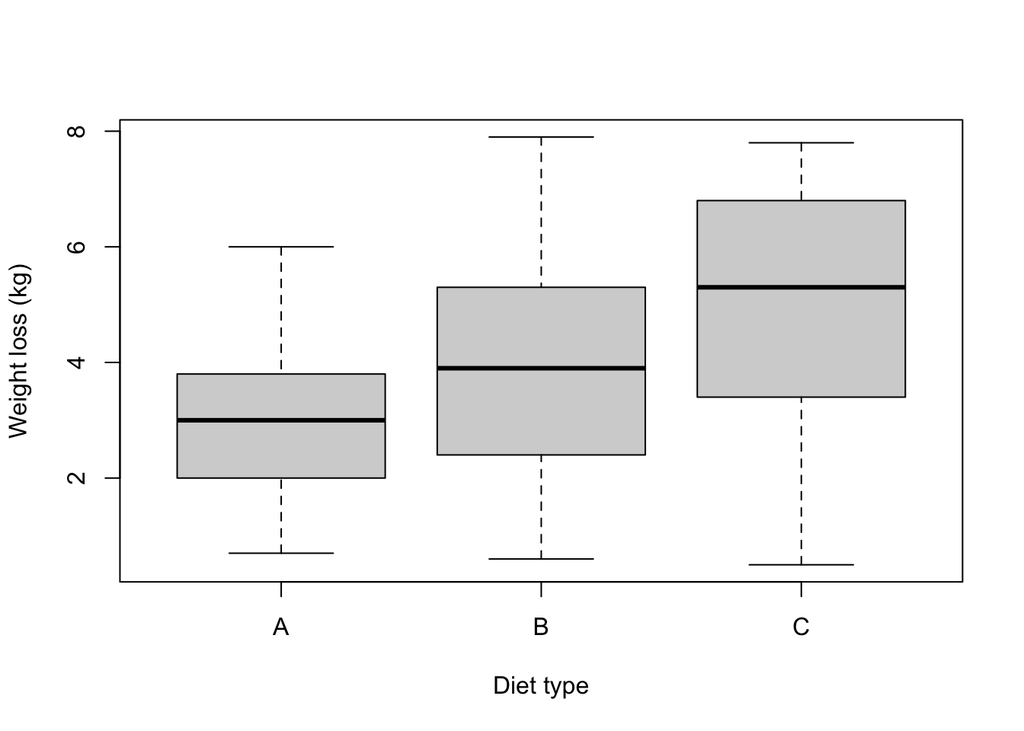

Данные по типам диет не являются сбалансированными, так как количества наблюдений везде разлчные.

```
##
##  A  B  C
## 21 22 25
```

Размер выборки больше, чем десятикратное количество групп.

Групповые средние и доверительные интервалы для типов диет:

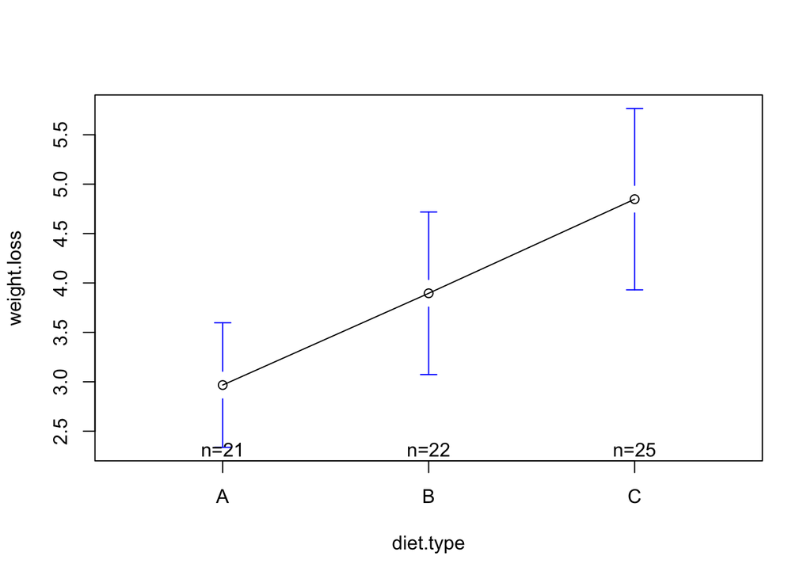

Суммарная статистика по типам диет относительно стандартного отклонения:

```
##   Group.1        x
## 1       A 1.384678
## 2       B 1.855616
## 3       C 2.223196
```

Стандартное отклонение для групп примерно одно. Максимальное для диеты типа С и минимальное - для А. По эффективности побеждает диета С, а уступает другим - А.

Подгонка дисперсионного анализа:

```
##             Df Sum Sq Mean Sq F value  Pr(>F)
## diet.type    2  40.53  20.263   5.745 0.00504 **
## Residuals   65 229.28   3.527
## ---
## Signif. codes:  0 '***' 0.001 '**' 0.01 '*' 0.05 '.' 0.1 ' ' 1
```

Результат F-теста свидетельствует, что разные по типу диеты неодинаково эффективны.

Множественное сравнение:

```
##   Tukey multiple comparisons of means
##     95% family-wise confidence level
##
## Fit: aov(formula = weight.loss ~ diet.type, data = data.noout)
##
## $diet.type
##          diff        lwr      upr     p adj
## B-A 0.9287879 -0.4455295 2.303105 0.2441535
## C-A 1.8813333  0.5478946 3.214772 0.0034358
## C-B 0.9525455 -0.3643199 2.269411 0.2000645
```

Из полученных результатов видно, что между типами диет А и В практически нет статистической разницы, как и между С и В, а вот между С и А она более значительна.

Визуализация межгрупповых различий:

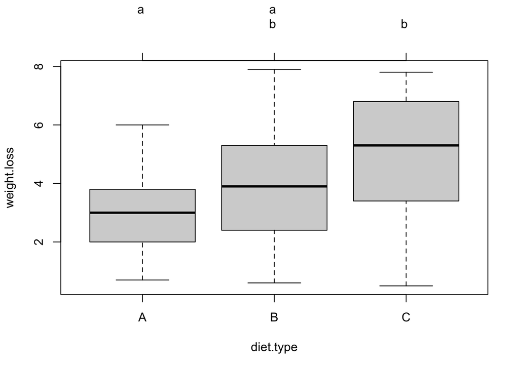

Видно, что диеты А и B статистически не отличаются (обозначены одинаковыми буквами), так же как B и C, а А и С различны.

Таким образом, при удалении выбросов, оказалось, что статисически диеты А и B, В и С дают одинаковые результаты. Однако, при сравнении диет А и С очевидно их сильное отличие. До устранения выбросов, наиболее эффективной была диета С, а наименее - В. Теперь же самой худшей диетой является А.

## Задания из файла

### Есть ли зависимость потери веса и пола?

Для изучения зависимости потерянных кг и пола, построены диаграмы размаха:

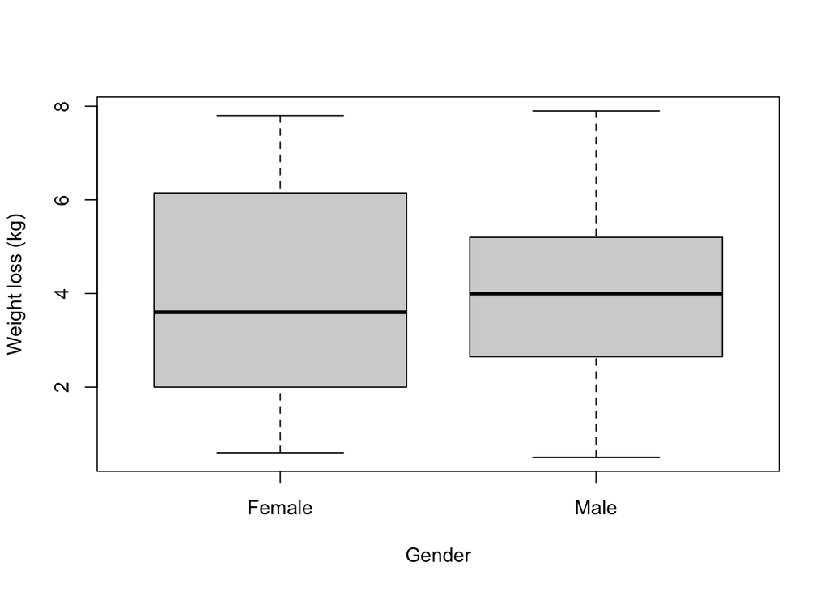

[output not shown]

Размер выборки больше, чем десятикратное количество групп.

Групповые средние:

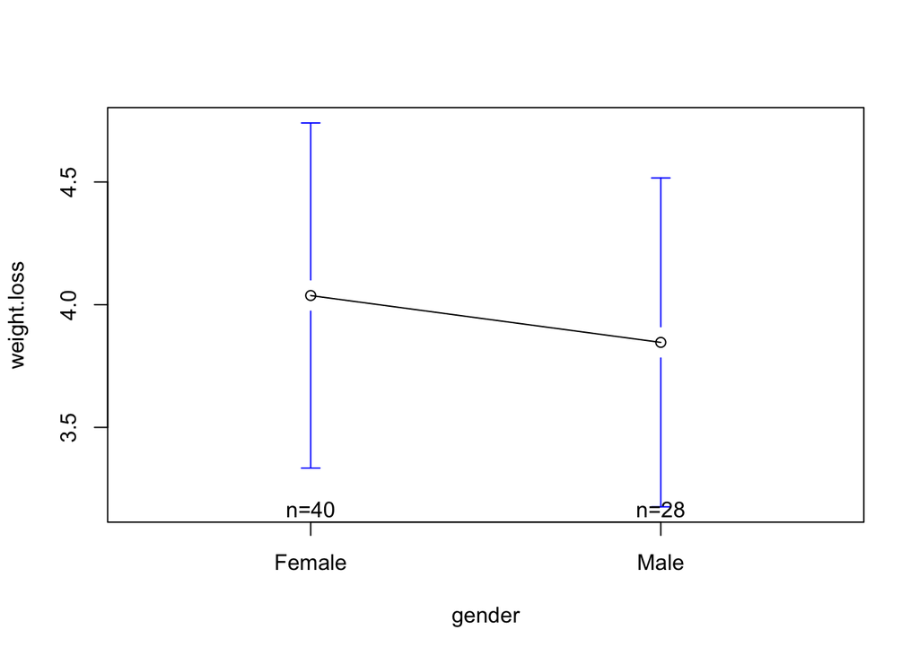

Суммарная статистика относительно стандартного отклонения:

```
##   Group.1        x
## 1  Female 2.198914
## 2    Male 1.728087
```

Стандартное отклонение для всех групп примерно одинаковое. Суммарная статистика относительно среднего значения:

```
##   Group.1        x
## 1  Female 4.037500
## 2    Male 3.846429
```

Женщинам несколько проще сбрасывать вес, чем мужчинам.

Подгонка дисперсионного анализа:

```
##             Df Sum Sq Mean Sq F value Pr(>F)
## gender       1    0.6   0.601   0.147  0.702
## Residuals   66  269.2   4.079
```

Результат F-теста статистически незначим. Пол и потерянные кг никак не связаны.

### Эффект от диеты и пол

```
##              Df Sum Sq Mean Sq F value   Pr(>F)
## typebygender  5  95.03  19.006   6.742 4.47e-05 ***
## Residuals    62 174.77   2.819
## ---
## Signif. codes:  0 '***' 0.001 '**' 0.01 '*' 0.05 '.' 0.1 ' ' 1
```

Результат F-теста статистически значим. Пол и эффект диеты связаны.

Множественное сравнение:

```
##   Tukey multiple comparisons of means
##     95% family-wise confidence level
##
## Fit: aov(formula = weight.loss ~ typebygender, data = data.noout)
##
## $typebygender
##                          diff         lwr        upr     p adj
## B.Female-A.Female  0.62756410 -1.34895742  2.6040856 0.9361983
## C.Female-A.Female  3.24923077  1.37830932  5.1201522 0.0000480
## A.Male-A.Female    0.88173077 -1.33690914  3.1003707 0.8498625
## B.Male-A.Female    2.02923077 -0.04752816  4.1059897 0.0591816
## C.Male-A.Female    0.66923077 -1.40752816  2.7459897 0.9322802
## C.Female-B.Female  2.62166667  0.70943955  4.5338938 0.0020510
## A.Male-B.Female    0.25416667 -1.99941461  2.5077479 0.9994417
## B.Male-B.Female    1.40166667 -0.71237996  3.5157133 0.3826560
## C.Male-B.Female    0.04166667 -2.07237996  2.1557133 0.9999999
## A.Male-C.Female   -2.36750000 -4.52905922 -0.2059408 0.0238163
## B.Male-C.Female   -1.22000000 -3.23566437  0.7956644 0.4859612
## C.Male-C.Female   -2.58000000 -4.59566437 -0.5643356 0.0048162
## B.Male-A.Male      1.14750000 -1.19449036  3.4894904 0.7022235
## C.Male-A.Male     -0.21250000 -2.55449036  2.1294904 0.9998074
## C.Male-B.Male     -1.36000000 -3.56804968  0.8480497 0.4662336
```

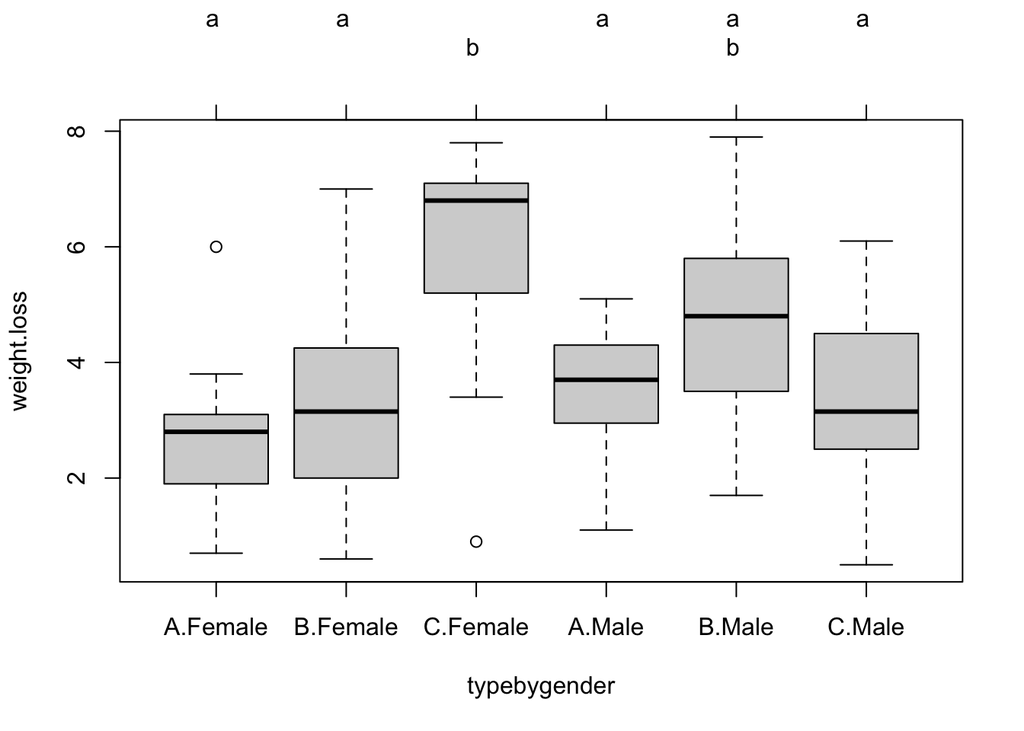

### Связан ли рост с эффективностью диеты от пола?

Подгонка дисперсионного анализа:

```
##                     Df Sum Sq Mean Sq F value   Pr(>F)
## typebygender         5  95.03  19.006   6.321 0.000102 ***
## height               1   0.76   0.765   0.254 0.615973
## typebygender:height  5   5.64   1.127   0.375 0.863812
## Residuals           56 168.37   3.007
## ---
## Signif. codes:  0 '***' 0.001 '**' 0.01 '*' 0.05 '.' 0.1 ' ' 1
```

Согласно F-тесту параметры не связаны.